# AP-4209 ESIEE-Paris: 2023 -2024

Projet 1 : Classification bayésienne

Adrien LINDEBERG – Théo LINDQVIST  
ESIEE Paris - DSIA

Introduction: Nous développerons un projet de classification bayésienne en utilisant l’ensemble de données sur les émotions ([Emotion Dataset](https://www.kaggle.com/datasets/abdallahwagih/emotion-dataset)). Notre dataset possède deux colonnes. - Comment: il s’agit d’un commentaire. - Emotion: il s’agit de l’émotion correspondant au commentaire. L’objectif sera de prédire l’émotion à partir du commentaire. Pour cela, nous allons employer une série de pré-traitement comme une tokenization ou une lemmatization et éventuellement étendre l’approche bayésienne pour inclure des ajustements (tuning) pour rendre notre modèle plus fiable et robuste.

Objectif principal : Développer un classificateur bayésien pour prédire les émotions à partir de données textuelles.

### 1. Chargement et exploration des données :

Dans un premier temps, nous allons explorer notre dataset afin de mieux comprendre comment il est constitué et mieux préparer le prétraitement des données pour obtenir un modèle bayésien optimal.

On n’oublie pas d’effacer toutes les variables en mémoire au début de notre script (réinitialisation l’environnement)

```r
rm(list = ls())

gc()
```

```
##          used (Mb) gc trigger (Mb) max used (Mb)
## Ncells 524222 28.0    1167585 62.4   660382 35.3
## Vcells 960221  7.4    8388608 64.0  1770407 13.6
```

##### 1.1 Chargement du jeu de données dans R:

On charge les packages nécessaires:

```r
library(ggplot2)
library(lattice)
library(kableExtra)
library(caret)
library(e1071)
library(RColorBrewer)
library(wordcloud)
library(tidyverse)
library(stringr)
library(text)
library(tidytext)
library(textstem)
library(tm)
library(reshape2)
library(naivebayes)
```

On récupère notre dataset:

```r
df <- read.csv("Emotion_classify_Data.csv")
```

Affichage des cinq premières lignes de notre dataset avec kableExtra:

```r
df %>%
  head() %>%
  kbl() %>%
  kable_styling(bootstrap_options = "striped", full_width = FALSE,
                position = "center")
```

| Comment | Emotion |
| --- | --- |
| i seriously hate one subject to death but now i feel reluctant to drop it | fear |
| im so full of life i feel appalled | anger |
| i sit here to write i start to dig out my feelings and i think that i am afraid to accept the possibility that he might not make it | fear |
| ive been really angry with r and i feel like an idiot for trusting him in the first place | joy |
| i feel suspicious if there is no one outside like the rapture has happened or something | fear |
| i feel jealous becasue i wanted that kind of love the true connection between two souls and i wanted that | anger |

Comme dit dans l’introduction, notre dataset possède bien deux colonnes: Comment et Emotion.

##### 1.2 Analyse exploratoire des données (EDA):

Maintenant, nous allons analyser notre dataset.

Pour commencer, on veut connaître ces dimensions:

```r
cat("Dimensions de df : ", dim(df), "\n")
```

```
## Dimensions de df :  5937 2
```

Notre dataset possède plus de 5900 lignes et deux colonnes.

On obtient une vue synthétique de df avec la fonction str():

```r
str(df)
```

```
## 'data.frame':    5937 obs. of  2 variables:
##  $ Comment: chr  "i seriously hate one subject to death but now i feel reluctant to drop it" "im so full of life i feel appalled" "i sit here to write i start to dig out my feelings and i think that i am afraid to accept the possibility that "| __truncated__ "ive been really angry with r and i fe…
##  $ Emotion: chr  "fear" "anger" "fear" "joy" ...
```

Nos deux colonnes sont dont des strings.

On veut savoir si il ya des valeurs manquantes dans le dataset:

```r
cat("Nombre de valeurs manquantes de df : ", sum(is.na(df)), "\n")
```

```
## Nombre de valeurs manquantes de df :  0
```

```r
cat("Nombre de valeurs vides de df : ",
    sum(apply(df, 1, function(row) all(row == ""))), "\n")
```

```
## Nombre de valeurs vides de df :  0
```

Il n’y a pas de valeurs manquantes ni de valeurs vides dans notre dataset.

On veut connaître toutes les émotions possibles:

```r
cat("Valeurs de la colonne Emotion : ", unique(df$Emotion), "\n")
```

```
## Valeurs de la colonne Emotion :  fear anger joy
```

Nous avons donc 3 émotions possibles: colère, peur, joie. Chaque émotion correspont à une classe.

Maintenant, on veut connaître la distribution de la colonne Emotion:

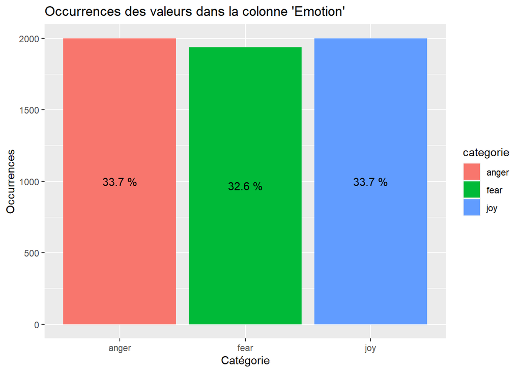

```r
occurrences <- table(df$Emotion)
occurrences_df <- as.data.frame(occurrences)
names(occurrences_df) <- c("categorie", "occurrences")

occurrences_df %>%
  ggplot(aes(x = categorie, y = occurrences, fill = categorie)) +
  geom_bar(stat = "identity") +
  geom_text(aes(label = paste(round(occurrences / nrow(df), 3) * 100, "%")),
            position = position_stack(vjust = 0.5)) +
  labs(title = "Occurrences des valeurs dans la colonne 'Emotion'",
       x = "Catégorie",
       y = "Occurrences")
```

On remarque que le nombre d’occurences de chaque émotions sont du même ordre de grandeur. Seul la peur compte un peu moins d’occurences mais cela reste négligeable.

On veut savoir quelles mots reviennent le plus dans la colonne Comment. Pouur cela on va transformer notre colonne Comment en corpus puis calculer la fréquence de chaque terme et afficher les mots qui reviennent le plus grâca à wordcloud:

```r
corpus <- Corpus(VectorSource(df$Comment))
corpus <- tm_map(corpus, content_transformer(tolower))
corpus <- tm_map(corpus, removePunctuation)
corpus <- tm_map(corpus, removeNumbers)
corpus <- tm_map(corpus, removeWords, stopwords("english"))
```

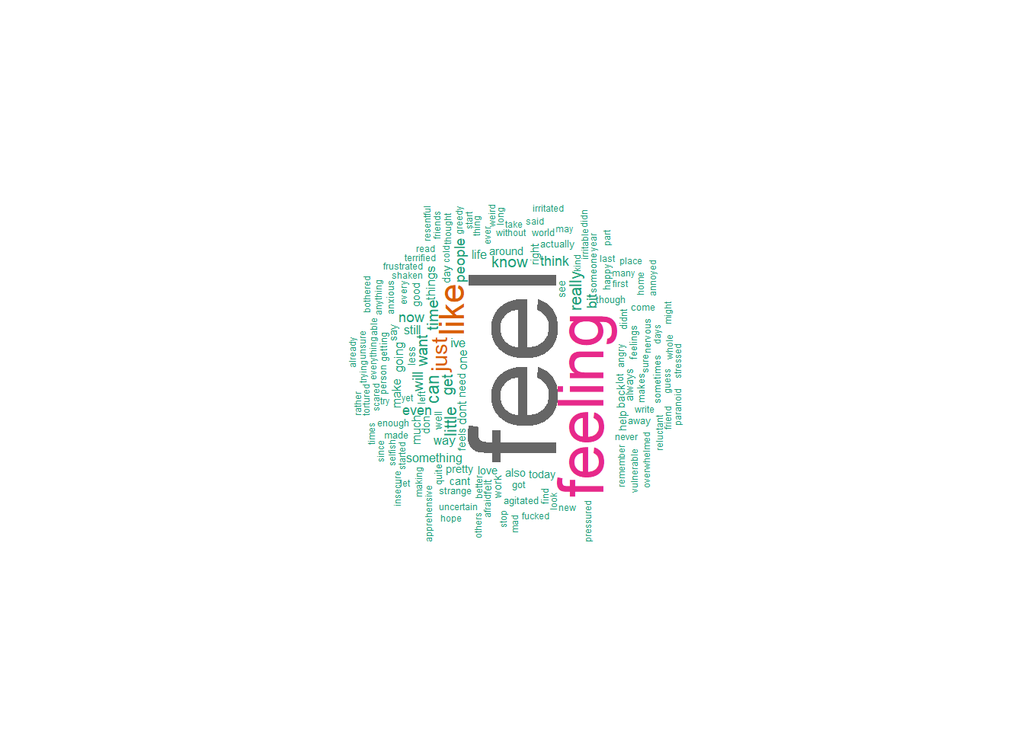

```r
tdm <- as.matrix(TermDocumentMatrix(corpus))

w <- sort(rowSums(tdm), decreasing = TRUE)
set.seed(222)
wordcloud(words = names(w),
          freq = w,
          max.words = 150,
          random.order = FALSE,
          min.freq = 5,
          colors = brewer.pal(8, "Dark2"),
          scale = c(5, 0.3),
          rot.per = 0.7)
```

On voit ainsi que feel et feeling sont les mots qui reviennent le plus souvent.

On veut savoir quelle est la longueurs des commentaires et si elle est liée à l’émotion.

Pour cela on va calculer la moyenne de la longueur des caractères mais aussi le minimum, le maximum et les quantiles:

```r
longueur <- nchar(df$Comment)

longueur_min <- min(longueur)
longueur_max <- max(longueur)
longueur_moyenne <- mean(longueur)
quantile_1 <- quantile(longueur, 0.25)
quantile_3 <- quantile(longueur, 0.75)

paste("Longueur minimale des commentaires:", longueur_min)
```

```
## [1] "Longueur minimale des commentaires: 9"
```

```r
paste("Longueur maximale des commentaires:", longueur_max)
```

```
## [1] "Longueur maximale des commentaires: 298"
```

```r
paste("Longueur moyenne  des commentaires:", round(longueur_moyenne))
```

```
## [1] "Longueur moyenne  des commentaires: 97"
```

```r
paste("1er quantile:", quantile_1)
```

```
## [1] "1er quantile: 54"
```

```r
paste("3ème quantile:", quantile_3)
```

```
## [1] "3ème quantile: 130"
```

Est ce que la taille des caractères est liée a l’émotion?

```r
df_anger <- df[df$Emotion == "anger", ]
df_fear <- df[df$Emotion == "fear", ]
df_joy <- df[df$Emotion == "joy", ]

#anger
longueur_anger <- nchar(df_anger$Comment)
longueur_anger_min <- min(longueur_anger)
longueur_anger_max <- max(longueur_anger)
longueur_anger_moyenne <- mean(longueur_anger)
quantile_anger_1 <- quantile(longueur_anger, 0.25)
quantile_anger_3 <- quantile(longueur_anger, 0.75)

#fear
longueur_fear <- nchar(df_fear$Comment)
longueur_fear_min <- min(longueur_fear)
longueur_fear_max <- max(longueur_fear)
longueur_fear_moyenne <- mean(longueur_fear)
quantile_fear_1 <- quantile(longueur_fear, 0.25)
quantile_fear_3 <- quantile(longueur_fear, 0.75)

#joy
longueur_joy <- nchar(df_joy$Comment)
longueur_joy_min <- min(longueur_joy)
longueur_joy_max <- max(longueur_joy)
longueur_joy_moyenne <- mean(longueur_joy)
quantile_joy_1 <- quantile(longueur_joy, 0.25)
quantile_joy_3 <- quantile(longueur_joy, 0.75)
```

Affichage:

```r
cat("anger:\nmoyenne: ", longueur_anger_moyenne, " - min: ", longueur_anger_min,
    " - max: ", longueur_anger_max, " - 1er quantile: ", quantile_anger_1,
    " - 3ème quantile: ", quantile_anger_3, "\nfear:\nmoyenne: ",
    longueur_fear_moyenne, " - min: ", longueur_fear_min,
    " - max: ", longueur_fear_max, " - 1er quantile: ", quantile_fear_1,
    " - 3ème quantile: ", quantile_fear_3, "\njoy:\nmoyenne: ",
    longueur_joy_moyenne, " - min: ", longueur_joy_min,
    " - max: ", longueur_joy_max, " - 1er quantile: ", quantile_joy_1,
    " - 3ème quantile: ", quantile_joy_3)
```

```
## anger:
## moyenne:  96.426  - min:  9  - max:  298  - 1er quantile:  51  - 3ème quantile:  131
## fear:
## moyenne:  96.1239  - min:  9  - max:  296  - 1er quantile:  54  - 3ème quantile:  126
## joy:
## moyenne:  99.687  - min:  13  - max:  298  - 1er quantile:  56  - 3ème quantile:  132
```

On remarque de peites variations que ce soit la moyenne des commentaires selon l’émotion. Cependant les variations sont faibles et ne permettent pas de faire de conclusion sur une relation entre la longueur d’un commentaire et l’émotion qui lui est liée.

### 2. Prétraitement des données :

Dans cette partie nous allons mettre en forme nos données pour le modèle bayésien.

##### 2.1 Nettoyage des données textuelles:

Dans un premier temps, nous allons supprimer les caractères spéciaux, les chiffres, les émojis et les mots vides des commentaires. Cette modication n’est pas nécessaire pour la colonne Emotion donc on se concentrera sur Comment.

Pour cela, on créé une foction clean_text:

```r
clean_text <- function(text) {
  #supprime les balises HTML
  text <- str_replace_all(text, "<.*?>", "")

  #convertie en minuscules
  text <- tolower(text)

  #supprimee les URLs
  text <- str_replace_all(text, "http\\S+", "")

  #supprime les caractères non alphanumériques et la ponctuation
  text <- str_replace_all(text, "[^a-zA-Z\\s]", "")

  #supprime les emojis
  text <- str_replace_all(text, "[\\x{10000}-\\x{1FFFF}]", "")

  #supprime les mots vides
  stopwords <- stopwords("en")
  stopwords_pattern <- paste0("\\b", paste(stopwords,
                                           collapse = "\\b|\\b"), "\\b")
  text <- str_replace_all(text, stopwords_pattern, "")

  #supprimer les mots court
  text <- str_split(text, "\\s+")[[1]]
  text <- text[str_length(text) > 2]

  #reforme les commentaire après le prétraitement
  preprocessed_text <- paste(text, collapse = " ")

  return(preprocessed_text)
}
```

On applique notre fonction à notre dataset:

```r
df <- df %>%
  mutate(Comment = sapply(Comment, clean_text))

#vérifie qu'il y a toujours pas de valeurs manquantes ou vides
sum(is.na(df$Comment))
```

```
## [1] 0
```

```r
sum(apply(df, 1, function(row) all(row == "")))
```

```
## [1] 0
```

On peut voir que les modifications ont bien eu lieu.

```r
df %>%
  head() %>%
  kbl() %>%
  kable_styling(bootstrap_options = "striped", full_width = FALSE,
                position = "center")
```

| Comment | Emotion |
| --- | --- |
| seriously hate one subject death now feel reluctant drop | fear |
| full life feel appalled | anger |
| sit write start dig feelings think afraid accept possibility might make | fear |
| ive really angry feel like idiot trusting first place | joy |
| feel suspicious one outside like rapture happened something | fear |
| feel jealous becasue wanted kind love true connection two souls wanted | anger |

##### 2.2 Application tokenization , stemming, ou lemmatization :

Tout d’abord, on va séparer la colonne Comment qui va nous servir de prédicteur et la colonne Emotion qui est la variable à prédire.

```r
X <- df[1]
Y <- df[2]
```

Affichage du prédicteur:

```r
X %>%
  head() %>%
  kbl() %>%
  kable_styling(bootstrap_options = "striped", full_width = FALSE,
                position = "center")
```

| Comment |
| --- |
| seriously hate one subject death now feel reluctant drop |
| full life feel appalled |
| sit write start dig feelings think afraid accept possibility might make |
| ive really angry feel like idiot trusting first place |
| feel suspicious one outside like rapture happened something |
| feel jealous becasue wanted kind love true connection two souls wanted |

Affichage de la varaible à prédire:

```r
Y %>%
  head() %>%
  kbl() %>%
  kable_styling(bootstrap_options = "striped", full_width = FALSE,
                position = "center")
```

| Emotion |
| --- |
| fear |
| anger |
| fear |
| joy |
| fear |
| anger |

```r
Y$Emotion <- factor(Y$Emotion, levels = unique(Y$Emotion))

Y %>%
  head() %>%
  kbl() %>%
  kable_styling(bootstrap_options = "striped", full_width = FALSE,
                position = "center")
```

| Emotion |
| --- |
| fear |
| anger |
| fear |
| joy |
| fear |
| anger |

On va maintenant appliquer une “tokenization” ainsi qu’une “lemmatization” et un “stemming” à X. On va passer d’une colone contenant une phrase à une colonne pour un mot.

Tokenization: c’est le processus de division d’un texte en unités plus petites appelées “tokens”. Un token peut être un mot, une phrase, ou même un caractère.

Stemming: c’est le processus de réduction des mots à leur racine ou base, en éliminant les suffixes.

Lemmatization: c’est une technique plus avancée que le stemming. Elle consiste à ramener les mots à leur forme canonique ou lemmatique, Contrairement au stemming, la lemmatisation produit des lemmes qui sont des mots valides dans la langue.

Pour cela, on code les deux fonctions suivantes:

```r
#applique la tokenization, la lemmatization et le stemming sur notre paramètre
tokenize <- function(sentence) {
  words <- unlist(strsplit(sentence, " "))
  stemming <- SnowballC::wordStem(words, language = "en")
  lemme <- lemmatize_words(stemming)
  return(lemme)
}

#modifie lst pour qu'elle soit de la longueur = longueur_max
fill_with_empty <- function(lst) {
  if (length(lst) < longueur_max) {
    return(c(lst, rep("", longueur_max - length(lst))))
  } else {
    return(lst)
  }
}
```

tokenize: prend en paramètre une phrase et revoit une liste avec un mot à chaque index où chaque mot a subi une lemmatization et un stemming permettant de revenir à la racine du mot.

fill_with_empty: prend en paramètre une liste et si elle plus petite que longueur_max alors cette fonction ajoute “” jusqu’à qu’elle soit de la taille longueur_max

On trasforme notre dataset grâce aux fonctions précédentes:

```r
X_token <- lapply(X$Comment, tokenize)
longueur_max <- max(sapply(X_token, length))
X_filled <- lapply(X_token, fill_with_empty)
X_final <- as.data.frame(do.call(rbind, X_filled))

colnames(X_final) <- paste0("mot_", seq_len(longueur_max))
rownames(X_final) <- paste0("", seq_len(nrow(X_final)))

remove_numbers <- function(x) gsub("\\d", "", x)
X_final <- mutate_all(X_final, remove_numbers)

X_final %>%
  head(10) %>%
  kbl() %>%
  kable_styling(bootstrap_options = "striped", full_width = FALSE,
                position = "center")
```

| mot_1 | mot_2 | mot_3 | mot_4 | mot_5 | mot_6 | mot_7 | mot_8 | mot_9 | mot_10 | mot_11 | mot_12 | mot_13 | mot_14 | mot_15 | mot_16 | mot_17 | mot_18 | mot_19 | mot_20 | mot_21 | mot_22 | mot_23 | mot_24 | mot_25 | mot_26 | mot_27 | mot_28 | mot_29 | mot_30 | … |
| --- | --- | --- | --- | --- | --- | --- | --- | --- | --- | --- | --- | --- | --- | --- | --- | --- | --- | --- | --- | --- | --- | --- | --- | --- | --- | --- | --- | --- | --- | --- |
| serious | hate | one | subject | death | now | feel | reluct | drop |  |  |  |  |  |  |  |  |  |  |  |  |  |  |  |  |  |  |  |  |  | … |
| full | life | feel | appal |  |  |  |  |  |  |  |  |  |  |  |  |  |  |  |  |  |  |  |  |  |  |  |  |  |  | … |
| sit | write | start | dig | feel | think | afraid | accept | possibl | may | make |  |  |  |  |  |  |  |  |  |  |  |  |  |  |  |  |  |  |  | … |
| ive | realli | angri | feel | like | idiot | trust | first | place |  |  |  |  |  |  |  |  |  |  |  |  |  |  |  |  |  |  |  |  |  | … |
| feel | suspici | one | outsid | like | raptur | happen | someth |  |  |  |  |  |  |  |  |  |  |  |  |  |  |  |  |  |  |  |  |  |  | … |
| feel | jealous | becasu | want | kind | love | true | connect | two | soul | want |  |  |  |  |  |  |  |  |  |  |  |  |  |  |  |  |  |  |  | … |
| friend | mine | keep | tell | morbid | thing | happen | dog |  |  |  |  |  |  |  |  |  |  |  |  |  |  |  |  |  |  |  |  |  |  | … |
| final | fall | asleep | feel | angri | useless | still | full | anxieti |  |  |  |  |  |  |  |  |  |  |  |  |  |  |  |  |  |  |  |  |  | … |
| feel | bite | annoy | antsi | good | way |  |  |  |  |  |  |  |  |  |  |  |  |  |  |  |  |  |  |  |  |  |  |  |  | … |
| feel | like | regain | anoth | vital | part | life | live |  |  |  |  |  |  |  |  |  |  |  |  |  |  |  |  |  |  |  |  |  |  | … |

Ce code transforme la colonne X$Comment en un dataframe où chaque mot est placé dans une colonne distincte, avec des chaînes vides pour les colonnes excédentaires. On utilise la méthode lapply pour bien appeler nos fonctions sur toutes les phrases. On a remarqué que la méthode lemmatize_words ajouté des chiffres pour certaines racines. On les a supprimés.

##### 2.3 Vectorisation du texte à l’aide de la « Term Frequency-Inverse Document Frequency » (TF-IDF) :

Après avoir appliqué une “tokenization”, un “stemming”, et une “lemmatization” à notre prédicteur, nous voulons maintenant vectoriser notre texte à l’aide de la fréquence des termes et de la fréquence inverse du document.

La fréquence des termes mesure à quelle fréquence un terme spécifique apparaît dans un document, tandis que la fréquence inverse du document évalue l’importance globale d’un terme en fonction de sa fréquence dans l’ensemble du dataset. La combinaison de ces deux mesures donne lieu à une représentation vectorielle qui met en évidence les termes distinctifs pour chaque lignes du dataset. Cela permettra d’obtenir une représentation numérique de nos commentaires textuels.

Tout d’abord on reconcatène les mots de chaque lignes pour obtenir la phrase du début mais avec le résultat du stemming et de la lemmatization.

```r
sentence <- data.frame(Comment = apply(X_final, 1, function(row) paste(row[row != ""], collapse = " ")))

sentence %>%
  head(10) %>%
  kbl() %>%
  kable_styling(bootstrap_options = "striped", full_width = FALSE,
                position = "center")
```

| Comment |
| --- |
| serious hate one subject death now feel reluct drop |
| full life feel appal |
| sit write start dig feel think afraid accept possibl may make |
| ive realli angri feel like idiot trust first place |
| feel suspici one outsid like raptur happen someth |
| feel jealous becasu want kind love true connect two soul want |
| friend mine keep tell morbid thing happen dog |
| final fall asleep feel angri useless still full anxieti |
| feel bite annoy antsi good way |
| feel like regain anoth vital part life live |

Nous allons maintenant procéder à la vectorisation du texte en utilisant la méthode de la fréquence des termes et de la fréquence inverse du document. Pour cela, on utilise la librairie tm et sa fonction DocumentTermMatrix.

Mais, pour utiliser cette méthode on doit transformer la colonne Comment en corpus.

C’est quoi un corpus? Un corpus est une structure de données utilisée pour stocker et organiser des textes. Il est souvent utilisé dans le domaine du traitement du langage naturel (NLP) et de l’analyse de texte. Un corpus peut contenir un ensemble de documents textuels, tels que des articles, des livres, des messages, etc.

```r
#créer un corpus
corpus <- iconv(sentence$Comment)
corpus <- Corpus(VectorSource(corpus))
corpus <- tm_map(corpus, tolower)
corpus <- tm_map(corpus, removePunctuation)
corpus <- tm_map(corpus, removeNumbers)
corpus <- tm_map(corpus, stripWhitespace)
cleanset <- tm_map(corpus, removeWords, stopwords("english"))
removeURL <- function(x) gsub("http[[:alnum:]]*", "", x)
cleanset <- tm_map(cleanset, content_transformer(removeURL))
cleanset <- tm_map(cleanset, stemDocument)
#représentation matricielle TF-IDF
dtm <- DocumentTermMatrix(corpus)
tfidf <- weightTfIdf(dtm)
tfidf <- as.matrix(tfidf)

tfidf[, 1:10] %>%
  head() %>%
  kbl() %>%
  kable_styling(bootstrap_options = "striped", full_width = FALSE,
                position = "center")
```

| death | drop | feel | hate | now | one | reluct | serious | subject | appal |
| --- | --- | --- | --- | --- | --- | --- | --- | --- | --- |
| 1.008454 | 1.008454 | 0.0036042 | 0.6188593 | 0.5039465 | 0.5356970 | 0.7365142 | 0.8902174 | 1.040622 | 0.000000 |
| 0.000000 | 0.000000 | 0.0081095 | 0.0000000 | 0.0000000 | 0.0000000 | 0.0000000 | 0.0000000 | 0.000000 | 2.303398 |
| 0.000000 | 0.000000 | 0.0029489 | 0.0000000 | 0.0000000 | 0.0000000 | 0.0000000 | 0.0000000 | 0.000000 | 0.000000 |
| 0.000000 | 0.000000 | 0.0036042 | 0.0000000 | 0.0000000 | 0.0000000 | 0.0000000 | 0.0000000 | 0.000000 | 0.000000 |
| 0.000000 | 0.000000 | 0.0040548 | 0.0000000 | 0.0000000 | 0.6026591 | 0.0000000 | 0.0000000 | 0.000000 | 0.000000 |
| 0.000000 | 0.000000 | 0.0029489 | 0.0000000 | 0.0000000 | 0.0000000 | 0.0000000 | 0.0000000 | 0.000000 | 0.000000 |

Maintenant on a une colonne par mot avec sa TF-IDF si ce mot était présent dans le commentaire initial.

### 3. Entraînement du modèle bayésien :

Maintenant que notre dataset est prêt, on va pouvoir utiliser un modèle bayésien pour prédire l’émotion liée à un commentaire.

Pour cela, on va utiliser le package e1071 R pour entraîner un classifieur bayésien naïf.

Tout d’abord, on va diviser nos données en un ensemble d’apprentissage et un ensemble de test. On décide que notre dataset d’entrainement possédera 80% des données.

```r
#sélectionne 80% des indexs au hasard
n <- nrow(tfidf)
index <- sample(1:n, 0.8 * n)

X_train <- tfidf[index, ]
y_train <- Y[index, ]
X_test <- tfidf[-index, ]
y_test <- Y[-index, ]

cat("Dimension du dataset d'entrainement : ", dim(X_train), "\n")
```

```
## Dimension du dataset d'entrainement :  4749 5938
```

```r
cat("Dimension du dataset de test : ", dim(X_test), "\n")
```

```
## Dimension du dataset de test :  1188 5938
```

On affiche les dimensions de nos ensembles pour être sûr qu’elles correspondent bien entre elles et qu’il n’y a pas d’erreur.

On utilise le modèle naiveBayes de la librairie e1071 sur nos ensembles d’entrainement puis on fait les prédictions:

```r
model_naif <- naiveBayes(X_train, y_train, m = 2)

predictions <- predict(model_naif, X_test)

predictions
```

```
##    [1] fear  fear  fear  anger fear  fear  fear  fear  fear  fear  fear  fear
##   [13] fear  fear  fear  fear  fear  fear  fear  fear  fear  fear  anger fear
##   [25] fear  fear  fear  fear  anger fear  fear  fear  fear  fear  fear  joy
##   [37] fear  fear  fear  fear  fear  fear  fear  anger fear  fear  fear  fear
##   [49] fear  fear  fear  fear  fear  fear  fear  fear  fear  anger fear  fear
##   [61] fear  fear  fear  anger anger fear  fear  fear  anger anger fear  fear
##   [73] anger anger fear  fear  fear  fear  fear  fear  fear  fear  fear  anger
##   [85] anger fear  fear  anger fear  fear  fear  fear  fear  fear  fear  fear
##   [97] fear  fear  fear  fear  fear  fear  fear  fear  fear  fear  fear  fear
##  [109] anger anger fear  fear  fear  fear  fear  fear  anger fear  fear  fear
##  [121] fear  fear  fear  fear  anger fear  fear  anger fear  fear  fear  fear
##  [133] fear  fear  fear  fear  fear  fear  anger fear  fear  fear  fear  fear
##  [145] fear  fear  fear  anger fear  fear  fear  fear  fear  anger fear  fear
##  [157] fear  anger anger anger anger anger fear  anger fear  fear  fear  fear
##  [169] fear  fear  fear  fear  fear  fear  fear  fear  fear  fear  fear  fear
```

[output cut: 85 more lines]

### 4. Évaluation du modèle :

Maintenant, on va évaluer notre modèle pour connaître ses performances.

##### 4.1 Calcul de l’exactitude, la précision, le rappel et le score F1 :

On veut connaître l’exactitude, la précision, le rappel et le score F1 de notre modèle pour se faire une idée plus précise.

Tout d’abord que représente ces métriques?

- Exactitude (Accuracy) : C’est le pourcentage total de prédictions correctes parmi toutes les prédictions. Calcul : (TP + TN) / (TP + TN + FP + FN)
- Précision (Precision) : C’est le pourcentage de prédictions positives correctes parmi toutes les prédictions positives. Calcul : TP / (TP + FP)
- Rappel (Recall) : C’est le pourcentage de prédictions positives correctes parmi toutes les instances réellement positives. Calcul : TP / (TP + FN)
- Score F1 (F1 Score) : C’est la moyenne harmonique de la précision et du rappel. Calcul : 2 * (Precision * Recall) / (Precision + Recall)

On va afficher le rapport de nos modèle:

```r
confusion_matrix <- confusionMatrix(predictions, y_test)

accuracy <- confusion_matrix$overall["Accuracy"]
mesure <- confusion_matrix$byClass[, c("Precision", "Recall", "F1")]

cat("Exactitude:", accuracy, "\n")
```

```
## Exactitude: 0.3737374
```

```r
mesure %>%
  kbl() %>%
  kable_styling(bootstrap_options = "striped", full_width = FALSE,
                position = "center")
```

|  | Precision | Recall | F1 |
| --- | --- | --- | --- |
| Class: fear | 0.3492872 | 0.8772379 | 0.4996358 |
| Class: anger | 0.4974874 | 0.2450495 | 0.3283582 |
| Class: joy | 0.2857143 | 0.0050891 | 0.0100000 |

On a une accuracy d’environ 37% ce qui est très faible.

On en conclut que notre modèle prédit par défaut fear et a du mal à identifier correctement les deux autres classe.

##### 4.2 Matrice de confusion :

On affiche la matrice de confusion pour mieux vizualiser la répartition des prédictions:

```r
matrice <- confusion_matrix$table

matrice %>%
  kbl() %>%
  kable_styling(bootstrap_options = "striped", full_width = FALSE,
                position = "center")
```

|  | fear | anger | joy |
| --- | --- | --- | --- |
| fear | 343 | 303 | 336 |
| anger | 45 | 99 | 55 |
| joy | 3 | 2 | 2 |

### 5. Amélioration du modèle :

On va chercher un nouveau modèle qui aura de meilleur résultats.

On teste le modèle multinomial_naive_bayes de la librairie naivebayes sur nos ensembles d’entrainement puis on fait les prédictions:

```r
model_multi <- multinomial_naive_bayes(x = X_train, y = y_train, laplace = 3)

predictions_multi <- predict(model_multi, X_test)

predictions_multi
```

```
##    [1] fear  anger joy   anger joy   joy   joy   joy   joy   anger anger fear
##   [13] anger anger joy   anger fear  fear  joy   fear  fear  joy   joy   joy
##   [25] fear  fear  fear  anger anger fear  joy   anger joy   fear  joy   joy
##   [37] joy   joy   anger anger fear  joy   anger fear  anger fear  anger joy
##   [49] anger anger anger anger fear  anger joy   fear  fear  anger joy   joy
##   [61] anger fear  fear  joy   fear  anger anger fear  anger anger fear  fear
##   [73] anger anger fear  joy   fear  joy   anger anger anger fear  anger fear
##   [85] fear  anger fear  anger fear  fear  fear  joy   anger fear  anger fear
##   [97] fear  fear  fear  fear  fear  joy   anger anger anger fear  fear  joy
##  [109] anger fear  anger fear  anger fear  fear  anger fear  joy   joy   anger
##  [121] fear  fear  fear  anger anger fear  anger anger fear  joy   anger fear
##  [133] joy   joy   joy   fear  fear  joy   joy   joy   joy   joy   joy   joy
##  [145] fear  fear  fear  joy   anger fear  fear  anger anger fear  fear  anger
##  [157] fear  anger anger anger anger joy   fear  joy   anger fear  joy   fear
##  [169] anger fear  anger joy   fear  anger joy   fear  joy   anger joy   fear
```

[output cut: 85 more lines]

on remarque déjà que comparé au modèle précédent, les prédictions du nouveau modèle semble largement mieux répartis entre les trois classes possibles.

On vérifie cela avec l’exactitude, la précision, le rappel et le score F1 du nouveau modèle:

```r
confusion_matrix_multi <- confusionMatrix(predictions_multi, y_test)

accuracy <- confusion_matrix_multi$overall["Accuracy"]
mesure <- confusion_matrix_multi$byClass[, c("Precision", "Recall", "F1")]

cat("Exactitude:", accuracy, "\n")
```

```
## Exactitude: 0.8821549
```

```r
mesure %>%
  kbl() %>%
  kable_styling(bootstrap_options = "striped", full_width = FALSE,
                position = "center")
```

|  | Precision | Recall | F1 |
| --- | --- | --- | --- |
| Class: fear | 0.8808933 | 0.9079284 | 0.8942065 |
| Class: anger | 0.8725962 | 0.8985149 | 0.8853659 |
| Class: joy | 0.8943089 | 0.8396947 | 0.8661417 |

On a une accuracy d’environ 88%. On regarde aussi les autres métriques:

- Pour la classe fear le modèle affiche une excellente précision de 88.09%, indiquant que la plupart des instances prédites comme fear sont correctes. Le recall de 90.79% indique que le modèle identifie efficacement la plupart des véritables instances de fear, et le score F1 de 89.42% met en évidence un bon équilibre entre précision et rappel.
- Pour la classe anger le modèle présente une précision élevée de 87.26% un recall de 89.85% et un score F1 de 88.54%.
- La classe joy montre de bons résultats avec une précision de 89.43% un recall de 83.97% et un score F1 de 86.61%.

Le modèle performe très bien sur l’ensemble des trois classe. Ses résultats sont incomparable au premier.

Pour finir, on affiche la matrice de confusion:

```r
matrice <- confusion_matrix_multi$table

matrice %>%
  kbl() %>%
  kable_styling(bootstrap_options = "striped", full_width = FALSE,
                position = "center")
```

|  | fear | anger | joy |
| --- | --- | --- | --- |
| fear | 355 | 20 | 28 |
| anger | 18 | 363 | 35 |
| joy | 18 | 21 | 330 |

La matrice de confusion confirme tout ce que l’on a dit précédement. On obtient en moyenne 350 bonne prédictions pour chaque classe et 40 échecs. Ce qui donne un ration de 9 bonnes prédictions sur 10 comme l’a montré l’accuracy. Ce modèle est beaucoup plus robuste et fiable que le précédent.

### 6. Conclusion :

Durant ce projet, on aura entraîné deux modèles, un modèle bayésien naïf et un modèle bayésien multinomial. Après les avoir évalués, on conclut:

Performance des modèles :

Le modèle bayésien naïf a montré une précision globale d’environ 37%, ce qui indique que ses prédictions ne sont pas du tout fiables. En analysant plus en détail, on a constaté que le modèle prédisé par défaut fear.

Amélioration avec le modèle multinomial :

En comparant avec le modèle bayésien multinomial, on observe une amélioration non négligeabme de la précision globale, qui atteint 88%.

On en conclut que le modèle naif n’est pas du tout optimal pour notre problèmes et serait plus utille pour un modèle bayésien binaire tandis que le modèle multinomial répond totalement à notre demande initial qui est de prédire l’émotion d’un commentaire.